# EsRegressioneLineare

Marco Bresciani

2022-08-08

## 1. Si produca un graﬁco dei dati. La relazione tra le variabili in esame appare lineare?

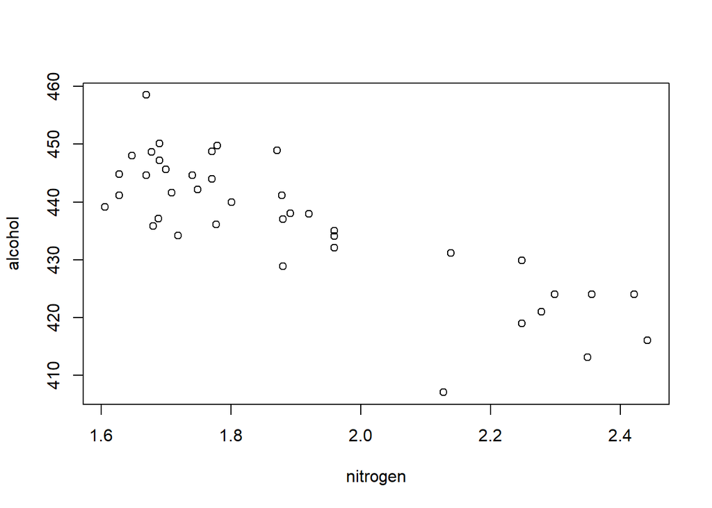

```r
grains<-read.table("datasets/grains.dat", header=TRUE)
model<-lm(alcohol~nitrogen, data=grains)
plot(alcohol~nitrogen, data=grains)
```

```r
summary(model)
```

```
##
## Call:
## lm(formula = alcohol ~ nitrogen, data = grains)
##
## Residuals:
##      Min       1Q   Median       3Q      Max
## -21.0588  -2.8736   0.3611   3.5560  13.4889
##
## Coefficients:
##             Estimate Std. Error t value Pr(>|t|)
## (Intercept)  506.871      7.839  64.661  < 2e-16 ***
## nitrogen     -37.034      4.096  -9.041 5.21e-11 ***
## ---
## Signif. codes:  0 '***' 0.001 '**' 0.01 '*' 0.05 '.' 0.1 ' ' 1
##
## Residual standard error: 6.482 on 38 degrees of freedom
## Multiple R-squared:  0.6826, Adjusted R-squared:  0.6743
## F-statistic: 81.74 on 1 and 38 DF,  p-value: 5.208e-11
```

La relazione appare lineare, vista la negatività di β, possiamo dire che le due variabili siano correlate negativamene

## 2. Si dia una stima puntuale per α e β.

```r
Beta<-cov(grains$alcohol,grains$nitrogen) / var(grains$nitrogen)
alpha<-mean(mean(grains$alcohol) - Beta * mean(grains$nitrogen))
alpha
```

```
## [1] 506.8706
```

```r
Beta
```

```
## [1] -37.03356
```

## 3. Si dia una stima intervallare ad un livello di conﬁdenza di 99% per α e β.

```r
a<-0.01
BConfInt<- Beta + c(-1,1) * qt(1-a/2, df =38) * 4.096
aConfInt<- alpha + c(-1,1) * qt(1-a/2, df = 38) * 7.839

BConfInt
```

```
## [1] -48.14010 -25.92702
```

```r
aConfInt
```

```
## [1] 485.6147 528.1265
```

```r
#contro prova
confint(model,level = 1-a)
```

```
##                 0.5 %    99.5 %
## (Intercept) 485.61483 528.12633
## nitrogen    -48.14073 -25.92639
```

## 4. Quali sono le assunzioni necessarie per poter aver stime puntuali per i valori α e β? Quali ## sono le assunzioni necessarie per poter ottenere delle stime intervallari per α e β?

Le assunzioni da fare sono quella di una distribuzione normale dei rumori, quindi che epsilon~N(0,sd^2), indipendente da X e indipendente tra le osservazioni, sotto questa prima assunzione ne deriva che lo stimatore di alpha e Beta siano distribuite Normalmente

## 5. Si aggiunga la retta delle relazione stimata tra alcohol e nitrogen al graﬁco ottenuto al punto 1.

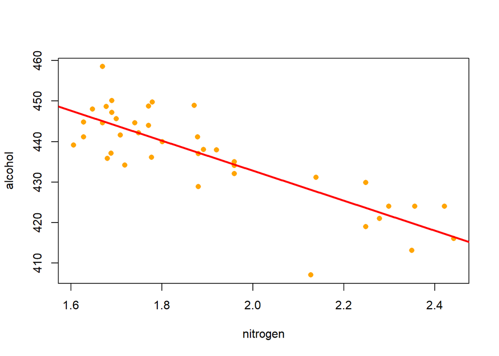

```r
plot(alcohol~nitrogen, data=grains, pch=16, col="orange")
abline(model, col="red", lwd=2.5)
```

## 6. Il dataset contiene la variabile location. Si scriva in forma estesa il modello che R stima quando si usa la funzione lm(alcohol~location, data = grain).

```r
library(fastDummies)
```

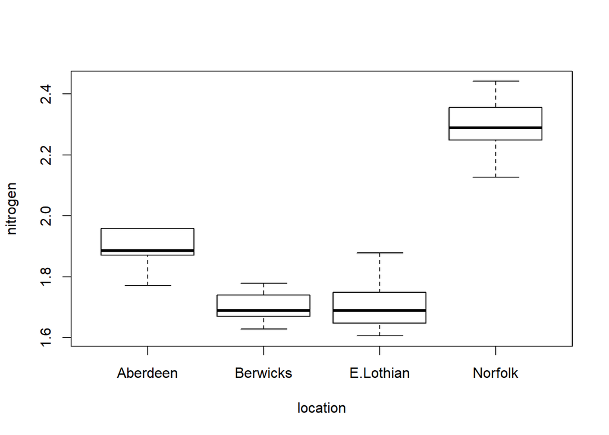

```r
plot(nitrogen~location, data=grains)
```

```r
#grains<-transform(grains, Aberdeen = ifelse(location=="Aberdeen", 1, 0 ))
#grains<-transform(grains, Berwicks = ifelse(location=="Berwicks", 1, 0 ))
#grains<-transform(grains, E.Lothian = ifelse(location=="E.Lothian", 1, 0 ))
#grains<-dummy_cols(grains, select_columns = "location")
model_q <- lm (alcohol ~ (location) , data=grains)
summary(model_q)
```

```
##
## Call:
## lm(formula = alcohol ~ (location), data = grains)
##
## Residuals:
##     Min      1Q  Median      3Q     Max
## -13.864  -3.753  -0.500   3.068  12.239
##
## Coefficients:
##                   Estimate Std. Error t value Pr(>|t|)
## (Intercept)        437.602      1.949 224.522  < 2e-16 ***
## locationBerwicks     8.682      2.756   3.150  0.00328 **
## locationE.Lothian    4.034      2.756   1.464  0.15199
## locationNorfolk    -16.693      2.756  -6.056 5.85e-07 ***
## ---
## Signif. codes:  0 '***' 0.001 '**' 0.01 '*' 0.05 '.' 0.1 ' ' 1
##
## Residual standard error: 6.163 on 36 degrees of freedom
## Multiple R-squared:  0.7282, Adjusted R-squared:  0.7055
## F-statistic: 32.15 on 3 and 36 DF,  p-value: 2.763e-10
```

Considerando il valore del p-value della statistica F possiamo dire che è possibile rigettare l’ipotesi nulla : H0: mean_Aberdeen = mean_Berwicks = mean_E.Lothian = mean_Norfolk

verificabile tramite l’analisi della varianza ANOVA

Questo significa che location è un predittore statisticamente significativo

## 7. E´ valida l’aﬀermazione che la variabile location spiega una buona parte della variabilit`a della variabile alcohol?

```r
aov(model_q)
```

```
## Call:
##    aov(formula = model_q)
##
## Terms:
##                 location Residuals
## Sum of Squares  3663.555  1367.554
## Deg. of Freedom        3        36
##
## Residual standard error: 6.16341
## Estimated effects may be unbalanced
```

```r
anova(model_q)
```

```
## Analysis of Variance Table
##
## Response: alcohol
##           Df Sum Sq Mean Sq F value    Pr(>F)
## location   3 3663.6 1221.19  32.147 2.763e-10 ***
## Residuals 36 1367.6   37.99
## ---
## Signif. codes:  0 '***' 0.001 '**' 0.01 '*' 0.05 '.' 0.1 ' ' 1
```

Cosiderando il modello sopra descritto e la seguente one way anova, per il valore della statistica F e del p-value estremamente basso pare che location abbia un impatto sulla variabile alcohol

## 8. Se si aggiunge la variabile location al modello in eq. (1) in cui solo nitrogen era presente nel modello, l’aggiunta di location risulta signiﬁcativa? Come si pu`o misurare l’evidenza controla non-inclusione di location nel modello?

```r
library(car)
model2<-lm(alcohol~nitrogen+(location), data = grains)
anova(model)
```

```
## Analysis of Variance Table
##
## Response: alcohol
##           Df Sum Sq Mean Sq F value    Pr(>F)
## nitrogen   1 3434.4  3434.4  81.738 5.208e-11 ***
## Residuals 38 1596.7    42.0
## ---
## Signif. codes:  0 '***' 0.001 '**' 0.01 '*' 0.05 '.' 0.1 ' ' 1
```

```r
anova(model2)
```

```
## Analysis of Variance Table
##
## Response: alcohol
##           Df Sum Sq Mean Sq F value    Pr(>F)
## nitrogen   1 3434.4  3434.4 89.8227 3.387e-11 ***
## location   3  258.4    86.1  2.2529   0.09938 .
## Residuals 35 1338.2    38.2
## ---
## Signif. codes:  0 '***' 0.001 '**' 0.01 '*' 0.05 '.' 0.1 ' ' 1
```

```r
anova(model, model2)
```

```
## Analysis of Variance Table
##
## Model 1: alcohol ~ nitrogen
## Model 2: alcohol ~ nitrogen + (location)
##   Res.Df    RSS Df Sum of Sq      F  Pr(>F)
## 1     38 1596.7
## 2     35 1338.2  3    258.43 2.2529 0.09938 .
## ---
## Signif. codes:  0 '***' 0.001 '**' 0.01 '*' 0.05 '.' 0.1 ' ' 1
```

L’aggiunta delle variabile Location sembra aver si abbassato Residuals Standard Square RSS però sembra essere significativa ad un livello del 10%, più piccolo è il residuo mieglio il modello fitta con i dati

## 9. Si produca un graﬁco della relazione tra location e nitrogen - cosa si pu`o notare?

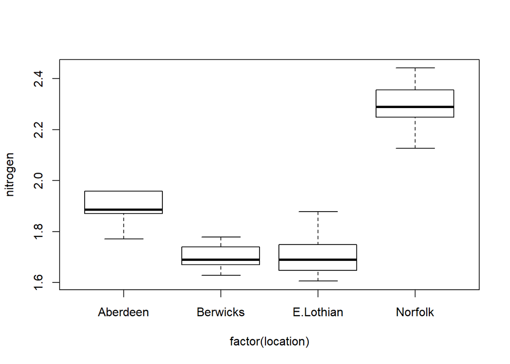

```r
scatterplot(nitrogen~factor(location), data=grains)
```

## 10. Come si spiega la diﬀerenza dei p-value per location nei modelli stimati al punto 6 e al punto 8?

```r
step(model, scope = list(upper=model2), direction = "both", trace=1)
```

```
## Start:  AIC=151.47
## alcohol ~ nitrogen
##
##            Df Sum of Sq    RSS    AIC
## + location  3     258.4 1338.2 150.41
## <none>                  1596.7 151.47
## - nitrogen  1    3434.4 5031.1 195.38
##
## Step:  AIC=150.41
## alcohol ~ nitrogen + location
##
##            Df Sum of Sq    RSS    AIC
## - nitrogen  1    29.305 1367.5 149.28
## <none>                  1338.2 150.41
## - location  3   258.427 1596.7 151.47
##
## Step:  AIC=149.28
## alcohol ~ location
##
##            Df Sum of Sq    RSS    AIC
## <none>                  1367.6 149.28
## + nitrogen  1      29.3 1338.2 150.41
## - location  3    3663.6 5031.1 195.38
```

```
##
## Call:
## lm(formula = alcohol ~ location, data = grains)
##
## Coefficients:
##       (Intercept)   locationBerwicks  locationE.Lothian
##           437.602              8.682              4.034
##   locationNorfolk
##           -16.693
```

## 11. Usando il modello speciﬁcato in eq. (1): si predica il valore medio della resa di alcool per del grano contenente il 1.9% e il 2.7% di azoto per kilogrammo.

```r
#alcohol ~ nitrogen
predict(model, newdata = data.frame(nitrogen=c(1.9,2.7)), level = "prediction", se.fit = TRUE)
```

```
## $fit
##        1        2
## 436.5068 406.8800
##
## $se.fit
##        1        2
## 1.024973 3.444202
##
## $df
## [1] 38
##
## $residual.scale
## [1] 6.482113
```

```r
confInterval<-predict(model, newdata=data.frame(nitrogen=c(1.9,2.7)),interval = "confidence", level = 1-0.05/2)
confInterval
```

```
##        fit      lwr      upr
## 1 436.5068 434.1148 438.8988
## 2 406.8800 398.8422 414.9178
```

il primo intervallo è più stretto rispetto al secondo poichè il valore di X=1.9 si avvicina molto a quella che è la media del campione
$$\text{Confidence intervals: }\hat{m}(x) \pm t_{\alpha/2, n - 2} \times
s_e\sqrt{\frac{1}{n}+\frac{(x-\bar{x})^2}{\sum_{i =
1}^n(x_i-\overline{x})^2}}$$
I parametri che influiscono sull’ampiezza dell’intervallo sono : 1)il livello di confidenza :
$$t_{\alpha/2,
n - 2}$$
2)la numerosità del campione :
$$n$$
3)media:
$$(x-\bar{x})^2$$

```r
p<-predict(model, newdata=data.frame(nitrogen=c(1.9,2.7)))
predInterval<-predict(model, newdata=data.frame(nitrogen=c(1.9,2.7)),interval = "prediction", level = 1-0.05/2)
p;predInterval
```

```
##        1        2
## 436.5068 406.8800
```

```
##        fit      lwr      upr
## 1 436.5068 421.1914 451.8222
## 2 406.8800 389.7497 424.0102
```

Come sappiamo l’intervallo di predizione risulta più ampio rispetto al relativo intervallo di confidenza, questo perchè l’intervallo di predizione tiene di conto della variabilità di Y sqrt(1+…)